# The Origins of Agriculture

## *Homo sapiens* have been around for 300,000 years

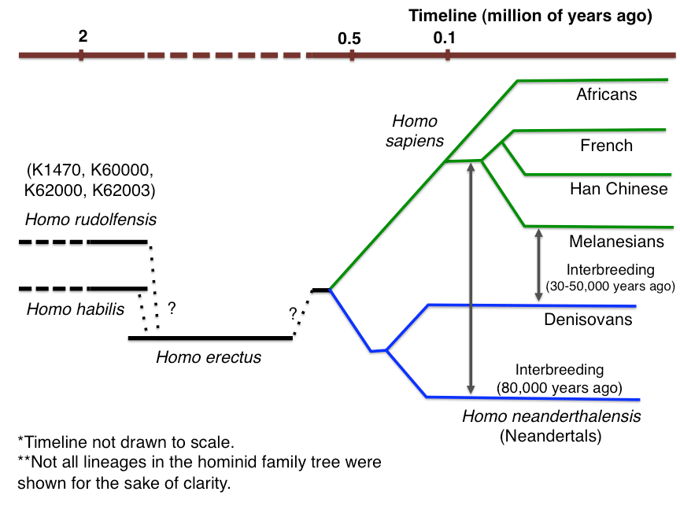

## Foraging societies

- **Foragers gather food provided by nature**
  - still practiced by indigenous cultures
  - https://youtu.be/Pro6X_Kc5wA
- **In Homo spp; smarter, cooperative foraging for high-calorie, high-quality foods fed more energy to the body, which made it possible to afford and then favor bigger, more expensive brains!!**
- **Does NOT imply a vegetarian diet**
  - Arctic Inuits = only meat
  - Hadza of Tanzania = vegetarian
  - !Kung of S. Africa = plants, eggs, fish, meat

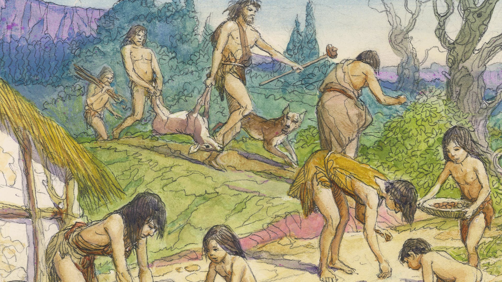

## Early foragers

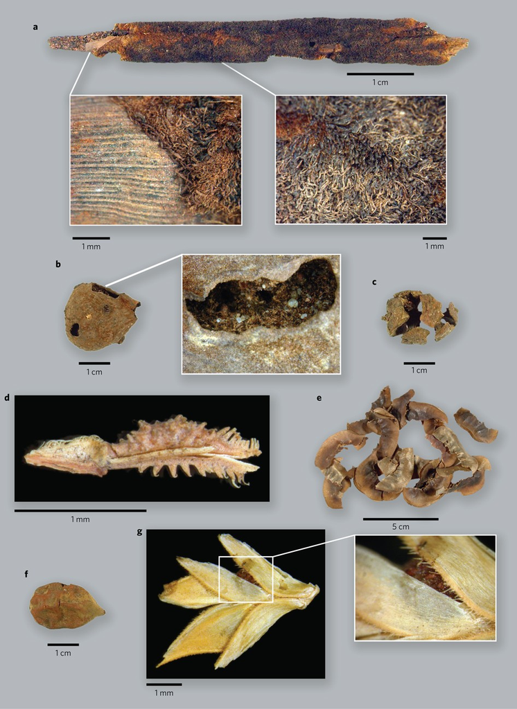

- **Fossil evidence reveals the diets of early foragers**
  - charred seeds & preserved fruits
  - bones, shells & feathers
- **Coprolites: fossilized poop!**
  - pollen forensics helps recreate diets
- **Tool remains and cave drawings reveal meat diet**
- **17,000 years ago: Wadi-Kubbaaniya in Nile Valley**
  - 25 plant species
  - tubers of grasses with high starch
  - plants needed to be ‘processed’

## Modern foragers

- **Evidence from key modern foraging societies**
  - !Kung from tropical African savannas
  - most studied remaining gatherer communities
- **10,000 years of foraging history**
  - continuing today
- **!Kung forage over 100 species of plants and 50 animal species**
  - 2355 kilocalories a day
  - 96 grams of protein
  - adequate vitamins and minerals
- **Dedicated division of labor along gender lines**
  - foraging = 2.5 days a week

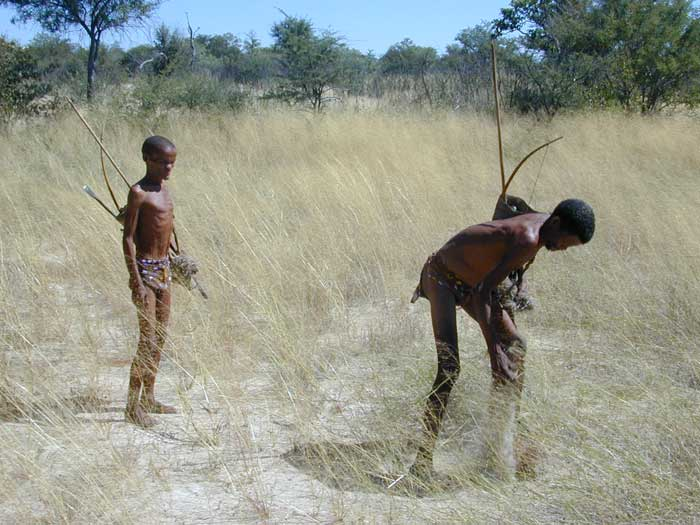

## Paleo diet (Caveman’s diet)

- **Recent diet trends relate to foraging past**
  - similar to hunter-gatherer periods
- **No dairy, refined grains or sugars or legumes**
  - none available for past foragers
- **Eat large quantities of meats, fruits, nuts, root vegetables and honey**
  - human body ‘adapted’ for this diet
- **Based on the fallacy that humans bodies have not evolved**
  - lactase gene now ‘stays on’ passed infancy
  - assumes one kind of forager diet

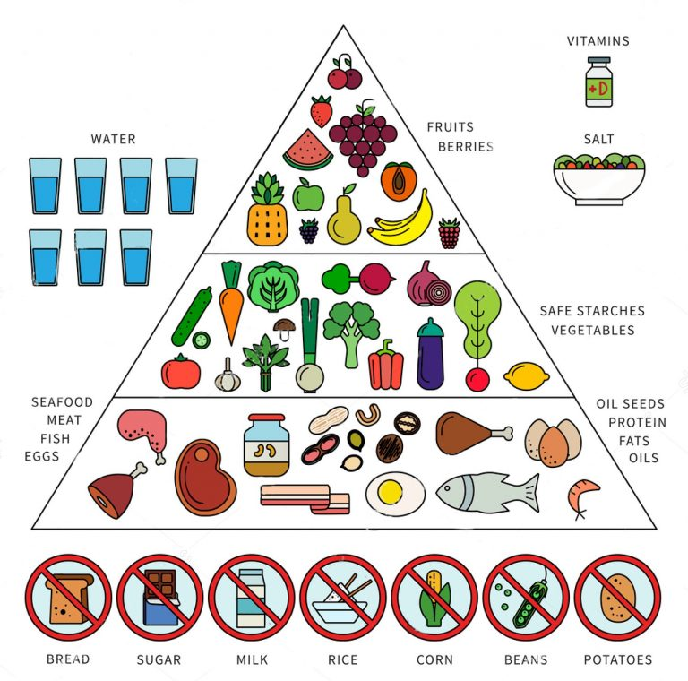

## Agriculture: Revolution of evolution?

- **Archaeology shows plant cultivation started ~10,000 years ago**
- **Agriculture flourished in Near East, Far East and Mesoamererica for thousands of years**
- **Question: Why the switch?**
  - a brilliant sage saw the power of seeds?
  - was the transition a revolution?
  - did a gradual cultural evolution take place?
  - was it climate related?

[figure not shown]

## End of an ice age….Neolithic Revolution

**Around 10,000 to 12,000 years ago, the Earth’s climate began to warm significantly, marking the end of the last glacial period**

**Created a more stable environment with a longer growing season and more varied plant life**

**Climate shifts led to wildfires and soil erosion, which may have created fertile valley basins**

**Allowed humans to stay in one area and develop farming/animal husbandry instead of relying on foraging**

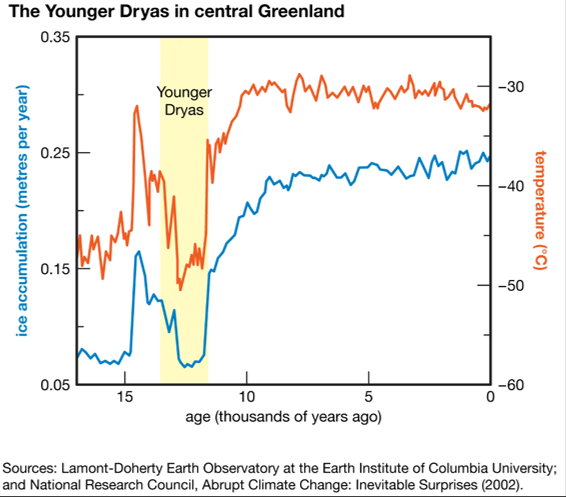

## Early sites of agriculture

- **Farming didn’t appear in one place and spread everywhere**
- **Started independently multiple times:**
  - Fertile Crescent (wheat/barley)
  - China (millet/rice)
  - New Guinea (taro/bananas)
  - Africa (sorghum/millet/rice)
  - Mesoamerica (maize/beans/squash)
  - Andes (potato/quinoa/llama)
  - Eastern N. America (native seed crops)
- **Those cores radiated outward and mixed**

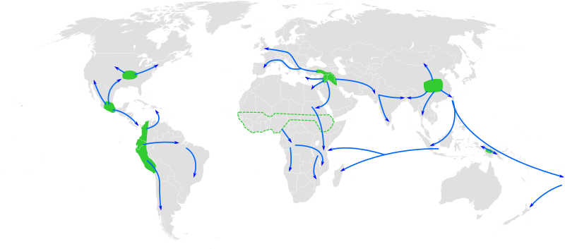

## The Near East: Fertile Crescent (~11,500 years ago)

- **Iran, Iran, Turkey, Syria, Lebanon and Israel**
  - some of the oldest sites of agriculture

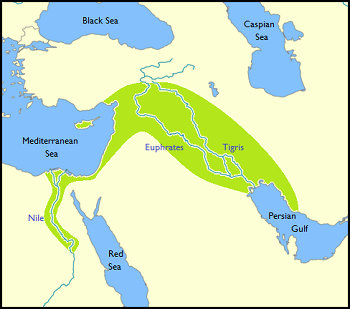

## The Near East: Fertile Crescent (~11,500 years ago)

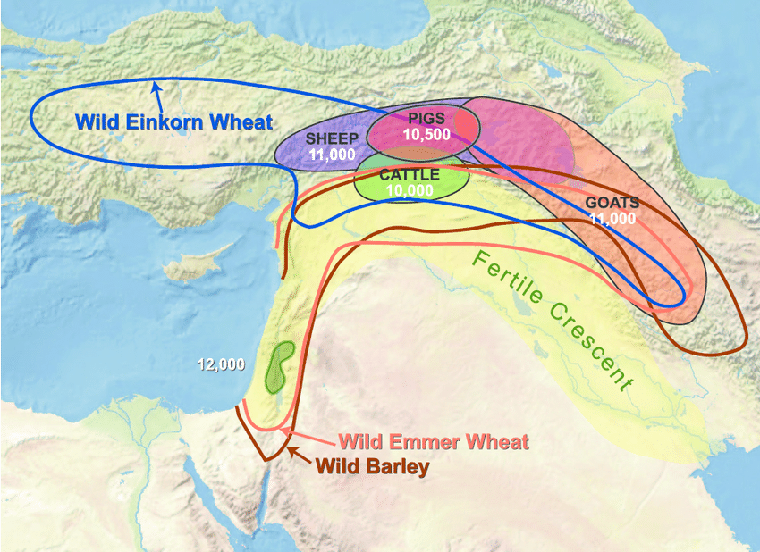

## The Far East: Yellow and Yangtze River Valleys

- **Rice cultivation began 11,500 years ago**
  - farming then spread up- and down streams
- **Domestication of millet, hemp, pigs, cattle & poultry after rice**
- **Silkworm domestication 5,000 years ago**
  - 354 genes differ between domestic & wild
- **Horse domestication 5,000 years ago**
  - Batai from plains of Central Asia

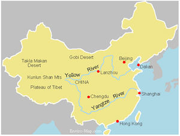

## The New World: Mexico and Peru

- **Timing of plant domestication matches Fertile Crescent and Far East**
- **Domestication of plants dominant**
  - squash, corn, peppers, beans, avocado & potatoes
- **Fewer animals domesticated**
  - dogs, turkeys, alpacas & guinea pigs
- **Archaeology points to Peru for farming origins**
- **Corn domestication in central Mexico**
  - 5,000 years ago (found in caves)
  - arrived in US ~2,000 years ago

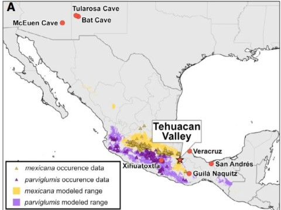

## The role of Appalachia in the history of agriculture

- **Indigenous peoples in and around the Appalachian region were farming and domesticating their own plants**
  - called the Eastern Agricultural Complex.
- **Key native plants were managed, tended, and selectively bred in river valleys that cut through the Appalachian region**
  - Ohio River, Tennessee River, Cumberland River
  - goosefoot seeds, sumpweed seeds (oil),
  - sunflower (seeds and oil), squash, barley (starch)
- **Patchy geography supported lots of parallel small-scale domestication experiments**
- **Maize, beans, and squash (“Three Sisters”) became staples later**

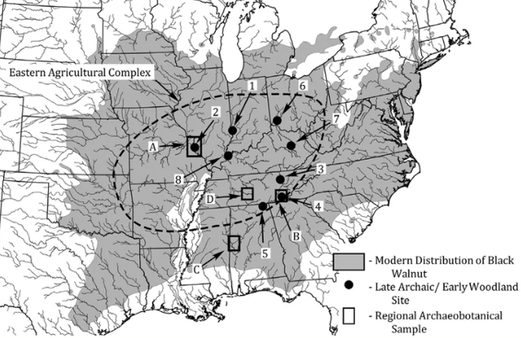

## Theory of Latitudinal Spread (Jared Diamond)

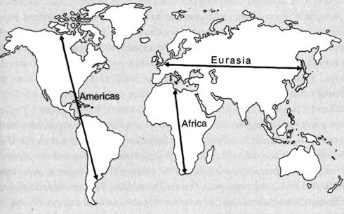

- **Theory of development & spread of agriculture**
  - certain areas of the world & not it others
  - 0.7 miles per year
- **East-West orientation in Eurasia**
  - crops & livestock outward from fertile crescent
- **North-South orientation in Americas**
  - crops from Mexico to US (.5 miles/year)
  - llama spread Peru to Ecuador (.2 miles/year)
- **Direction of domestication interacts with climate!**
  - moving the agricultural knowledge N-S includes big climate shifts, which slowed spread

## European Stone Age

- **Farming spread from Near East**
  - first to Turkey, Greece and Bulgaria
  - ~7500 years ago farming spread to rest of Europe
- **DNA from ancient European foragers compared to earliest farmers**
  - 15,000 - 4,300 years ago
  - *not related*!!!
- **DNA also compared to modern Europeans**
  - modern Europeans related to farmers, not foragers
  - first farmers were immigrants, that spread agriculture

[figure not shown]

## Global population tied to agriculture

**The human population increased from ~5 million to 50 million during and shortly after the first agricultural revolution. This increase was due to a more stable and abundant food supply from farming, which allowed for a larger, settled population that could also support higher birth rates.**

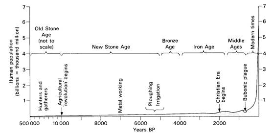

## Characteristics of domesticated plants

- **Domesticated plants genetically distinct**
  - artificial vs natural selection
- **Wild plants: selection pressures from the environment**
  - traits have ‘survival value’
- **Domesticated plants: traits are breed to suit human needs**
  - not always advantageous
- **Example: Ensheathing husks in corn or non-shattering heads wheat**

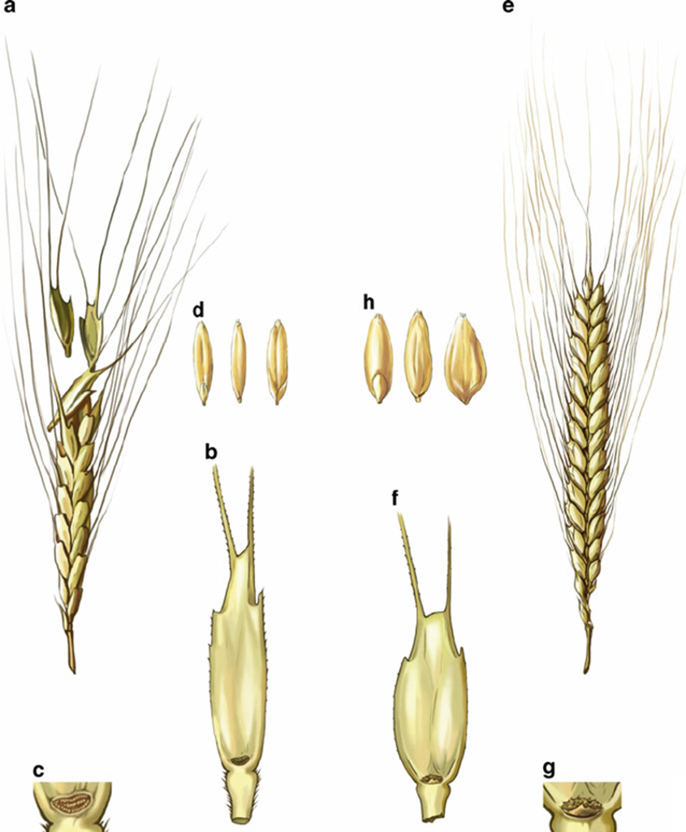

## Origins of key domesticated plants

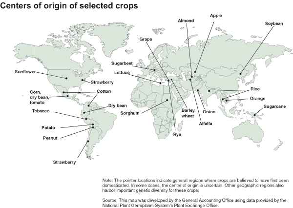

- **Vavilov (Russian botanist) proposed 8 centers of crop domestication**
  - highest diversity = origin
  - wild strains key for genetic diversity
- **Trading & migration expanded range of crops**
- **Some crops do better in new areas**
  - most of US crops are not native
  - coffee native to Ethiopia